# PML_PredictionAssignmentWriteup

Parmod Kumar

19 July 2015

## Background

Devices like Jawbone Up, Nike FuelBand, and Fitbit are part of the quantified self movement - a group of enthusiasts who take measurements for themselves regularly to improve their health, to find patterns in their behavior, or because they are tech geeks. In this project, we will use data from accelerometers on the belt, forearm, arm, and dumbbell of 6 participants. These participants were asked to perform barbell lifts correctly and incorrectly in 5 ways given below.

- A: exactly according to the specification
- B: throwing the elbows to the front
- C: lifting the dumbbell only halfway
- D: lowering the dumbbell only halfway
- E: throwing the hips to the front

For further information please refer to the section on the Weight Lifting Exercise Dataset at the website [here](http://groupware.les.inf.puc-rio.br/har).

## Data

The training data for this project can be found on this [link](https://d396qusza40orc.cloudfront.net/predmachlearn/pml-training.csv).

The test data can be consulted on this [link](https://d396qusza40orc.cloudfront.net/predmachlearn/pml-testing.csv).

The data for this project come from the source at [1].

## Goal

The goal of the project is to provide for the manner in which the exercise is done, i.e. how the model is built, how cross validation is used, what is the expected out sample error, and explain the choices made for this project.

## Loading the Data

Let’s first load the required library, set the seed and then load the training and testing data sets from the working directory.

```r
library(AppliedPredictiveModeling) # load 'AppliedPredictiveModeling' package
library(ggplot2) # load 'ggplot2' package
library(caret) # load 'caret' package
library(rattle) # load 'rattle' package
library(randomForest) # load 'randomForest' package
library(corrplot) # load 'corrplot' package
library(rpart) # load 'rpart' package
library(rpart.plot) # load 'rpart.plot' package
set.seed(1111) # specify seeds for reproducible purpose
# loading the training data
training <- read.csv("pml-training.csv", header=TRUE)
# loading the testing data
testing <- read.csv("pml-testing.csv", header=TRUE)
colnames_train <- colnames(training) # set column names of training
colnames_test <- colnames(testing) # set column names of testing
dim(training) # retrieve the dimension of training
```

```
## [1] 19622   160
```

```r
dim(testing) # retrieve the dimension of testing
```

```
## [1]  20 160
```

### Cleaning the data

Here, we will clean the data and get rid of observations with missing values as well as some meaningless variables.

```r
sum(complete.cases(training)) # count complete cases
```

```
## [1] 406
```

First, we remove columns that contain NA missing values.

```r
training <- training[, colSums(is.na(training)) == 0]
testing <- testing[, colSums(is.na(testing)) == 0]
```

Next, we get rid of some columns that do not contribute much to the accelerometer measurements.

```r
classe <- training$classe
trainRemove <- grepl("^X|timestamp|window", names(training))
training <- training[, !trainRemove]
trainCleaned <- training[, sapply(training, is.numeric)]
trainCleaned$classe <- classe
testRemove <- grepl("^X|timestamp|window", names(testing))
testing <- testing[, !testRemove]
testCleaned <- testing[, sapply(testing, is.numeric)]
```

Now, the cleaned training data set contains 19622 observations and 53 variables, while the testing data set contains 20 observations and 53 variables. The “classe” variable is still in the cleaned training set.

### Slice the data

Then, we can split the cleaned training set into a pure training data set (70%) and a validation data set (30%). We will use the validation data set to conduct cross validation in future steps.

```r
set.seed(1111) # specify seeds for reproducible purpose
inTrain <- createDataPartition(trainCleaned$classe, p=0.70, list=F)
trainData <- trainCleaned[inTrain, ]
testData <- trainCleaned[-inTrain, ]
```

## Data Modeling

We fit a predictive model for activity recognition using **Random Forest** algorithm because it automatically selects important variables and is robust to correlated covariates & outliers in general. We will use **5-fold cross validation** when applying the algorithm.

```r
controlRf <- trainControl(method="cv", number = 5)
modelRf <- train(classe ~ ., data=trainData, method="rf", trControl=controlRf, ntree=250)
modelRf
```

```
## Random Forest
##
## 13737 samples
##    52 predictor
##     5 classes: 'A', 'B', 'C', 'D', 'E'
##
## No pre-processing
## Resampling: Cross-Validated (5 fold)
## Summary of sample sizes: 10990, 10990, 10989, 10990, 10989
## Resampling results across tuning parameters:
##
##   mtry  Accuracy   Kappa      Accuracy SD  Kappa SD
##    2    0.9916282  0.9894091  0.001765934  0.002234914
##   27    0.9906819  0.9882124  0.001579484  0.001998877
##   52    0.9838387  0.9795544  0.004667691  0.005905892
##
## Accuracy was used to select the optimal model using  the largest value.
## The final value used for the model was mtry = 2.
```

Then, we estimate the performance of the model on the validation data set.

```r
predictRf <- predict(modelRf, testData)
confusionMatrix(testData$classe, predictRf)
```

```
## Confusion Matrix and Statistics
##
##           Reference
## Prediction    A    B    C    D    E
##          A 1672    2    0    0    0
##          B    3 1132    4    0    0
##          C    0   10 1014    2    0
##          D    0    0   19  945    0
##          E    0    0    1    2 1079
##
## Overall Statistics
##
##                Accuracy : 0.9927
##                  95% CI : (0.9902, 0.9947)
##     No Information Rate : 0.2846
##     P-Value [Acc > NIR] : < 2.2e-16
##
##                   Kappa : 0.9908
##  Mcnemar's Test P-Value : NA
##
## Statistics by Class:
##
##                      Class: A Class: B Class: C Class: D Class: E
## Sensitivity            0.9982   0.9895   0.9769   0.9958   1.0000
## Specificity            0.9995   0.9985   0.9975   0.9962   0.9994
## Pos Pred Value         0.9988   0.9939   0.9883   0.9803   0.9972
## Neg Pred Value         0.9993   0.9975   0.9951   0.9992   1.0000
## Prevalence             0.2846   0.1944   0.1764   0.1613   0.1833
## Detection Rate         0.2841   0.1924   0.1723   0.1606   0.1833
## Detection Prevalence   0.2845   0.1935   0.1743   0.1638   0.1839
## Balanced Accuracy      0.9989   0.9940   0.9872   0.9960   0.9997
```

```r
accuracy <- postResample(predictRf, testData$classe)
accuracy
```

```
##  Accuracy     Kappa
## 0.9926933 0.9907573
```

```r
oose <- 1 - as.numeric(confusionMatrix(testData$classe, predictRf)$overall[1])
oose
```

```
## [1] 0.007306712
```

## Predicting for Test Data Set

Now, we apply the model to the original testing data set downloaded from the data source. We remove the `problem_id` column first.

```r
result <- predict(modelRf, testCleaned[, -length(names(testCleaned))])
result
```

```
##  [1] B A B A A E D B A A B C B A E E A B B B
## Levels: A B C D E
```

## Appendix: Figures

1. Correlation Matrix Visualization

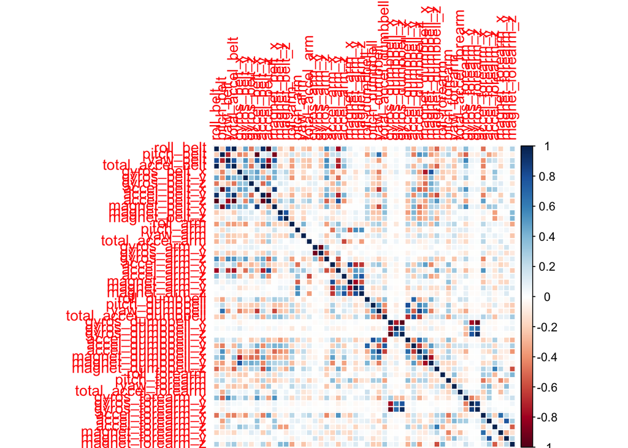

```r
corrPlot <- cor(trainData[, -length(names(trainData))])
corrplot(corrPlot, method="color")
```

2. Decision Tree Visualization

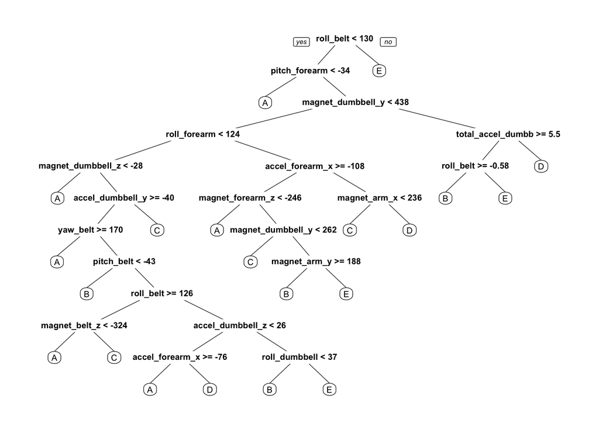

```r
treeModel <- rpart(classe ~ ., data=trainData, method = "class")
prp(treeModel) # plot an rpart model
```

## References

[1] Data Source. Available at: http://groupware.les.inf.puc-rio.br/har.